# Governance - Exploratory Factor Analysis

Olivia Beck

2024-01-22

This document is to run and EFA on the 2018 governance data set to late make a factor model to use to assign all orgs a “governance score”.

## Data and Libraries

```r
load("governance/governance.Rdata")

library(dplyr)
library(purrr)
library(tidyr)
library(kableExtra)
library(data.table)
library(polycor)
library(ggcorrplot)
library(psych)
```

## Making Design Matrix

1 is positive direction (i.e. good governance practices)

0 is negative direction (i.e. bad governance practices)

[output not shown]

```r
#For P6_LINE_1B / P6_LINE_1A >= 0.625
indep_members_threshold <- 0.5 #this is the median value for this data set


design_mat <-
  dat_govern %>%
  #dont need P6_SCHEDULE_O, P12_LINE_1_OTHER_EXPLAIN, RETURN TYPE
  select(- c(P6_SCHEDULE_O, P12_LINE_1_OTHER_EXPLAIN, RETURN_TYPE, P6_LINE_4)) %>%
  #remove all is.na in all columns except P6_LINE_10B, P6_LINE_12B, P6_LINE_12C, P6_LINE_16B, PM_LINE_31
  filter(if_all(-c(P6_LINE_10B, P6_LINE_12B, P6_LINE_12C, P6_LINE_16B, P6_LINE_18, PM_LINE_31),
                ~ !is.na(.))) %>%
  #P4 Line 12
  mutate(P4_LINE_12 = ifelse(P4_LINE_12A == "yes" | P4_LINE_12B == "yes", 1, 0)) %>%
  select(-c(P4_LINE_12A, P4_LINE_12B))%>%
  #P4 line 28
  mutate(P4_LINE_28 = ifelse(
    P4_LINE_28A == "yes" |
      P4_LINE_28B == "yes" |
      P4_LINE_28C == "yes" , 0, 1)) %>%
  select(-c(P4_LINE_28A, P4_LINE_28B, P4_LINE_28C)) %>%
  #P4 line 29 and 30, Schedule M
  mutate(P4_LINE_29_30 = case_when(
    P4_LINE_29 == "yes" & PM_LINE_31 == "no" ~ 0,
    P4_LINE_30 == "yes" & PM_LINE_31 == "no" ~ 0,
    TRUE ~ 1)) %>%
  select(-c(P4_LINE_29, P4_LINE_30, PM_LINE_31)) %>%
  #P6_LINE_1
  filter(P6_LINE_1A != 0) %>% # remove divide by 0 errors
  filter(P6_LINE_1A > P6_LINE_1B) %>% # only keep cases where we have more members than independent members
  mutate(P6_LINE_1 = ifelse(P6_LINE_1B / P6_LINE_1A >= indep_members_threshold, 1, 0)) %>%
  select(-c(P6_LINE_1B , P6_LINE_1A )) %>%
  #P6_LINE_2, 3, 5, 7A, 7B all have no as good and yes as bad
  mutate_at(vars("P6_LINE_2", "P6_LINE_3", "P6_LINE_5", "P6_LINE_7A", "P6_LINE_7B") ,
            ~ ifelse(. == "no", 1, 0)) %>%
  #P6_Line_10
  mutate(P6_LINE_10 = case_when(
    P6_LINE_10A == "no"  ~ 1,
    P6_LINE_10A == "yes" & P6_LINE_10B == "yes" ~ 1,
    P6_LINE_10A == "yes" & P6_LINE_10B == "no"  ~ 0
  )) %>%
  select(-c(P6_LINE_10A, P6_LINE_10B)) %>%
  #P6_LINE_12B
  mutate(P6_LINE_12B = case_when(
    P6_LINE_12A == "no"  ~ 1,
    P6_LINE_12A == "yes" & P6_LINE_12B == "yes" ~ 1,
    P6_LINE_12A == "yes" & P6_LINE_12B == "no"  ~ 0
  )) %>%
  #P6_LINE_12C
  mutate(P6_LINE_12C = case_when(
    P6_LINE_12A == "no"  ~ 1,
    P6_LINE_12A == "yes" & P6_LINE_12C == "yes" ~ 1,
    P6_LINE_12A == "yes" & P6_LINE_12C == "no"  ~ 0
  )) %>%
  #P6_LINE_16
  mutate(P6_LINE_16 = case_when(
    P6_LINE_16A == "no"  ~ 1,
    P6_LINE_16A == "yes" & P6_LINE_16B == "yes" ~ 1,
    P6_LINE_16A == "yes" & P6_LINE_16B == "no"  ~ 0
  )) %>%
  select(-c(P6_LINE_16A, P6_LINE_16B)) %>%
  # P6_LINE_18
  mutate(P6_LINE_18 = case_when(
    P6_LINE_18 == "own_website" ~ 1 ,
    is.na(P6_LINE_18) ~ 0,
    TRUE ~ 0
  )) %>%
  # All other P6 yes is good, no is bad
  mutate_at(vars( paste0("P6_LINE_", c("8A", "8B", "11A", "12A", 13, 14, "15A", "15B"))),
            ~  ifelse(. == "yes", 1, 0)) %>%
  # P12_LINE_1
  mutate(P12_LINE_1 = ifelse(P12_LINE_1 == "accrual", 1, 0)) %>%
  # P12_Line_2A
  mutate(P12_LINE_2A = ifelse(P12_LINE_2A == "no", 0, 1)) %>%
  # P12_Line_2B
  mutate(P12_LINE_2B = ifelse(P12_LINE_2B == "no", 0, 1)) %>%
  #P12_Line_2C
  mutate(P12_LINE_2C = case_when(
    P12_LINE_2A == "no" ~ 1,
    P12_LINE_2B == "no" ~ 1,
    P12_LINE_2A == "yes" & P12_LINE_2C == "yes" ~ 1,
    P12_LINE_2B == "yes" & P12_LINE_2C == "yes" ~ 1,
    P12_LINE_2A == "yes" & P12_LINE_2C == "no" ~ 0,
    P12_LINE_2B == "yes" & P12_LINE_2C == "no" ~ 0,
    TRUE ~ 0
  )) %>%
  #P12_Line_3
  mutate(P12_LINE_3 = case_when(
    P12_LINE_3A == "no" ~ 1,
    P12_LINE_3A == "yes" & P12_LINE_3B == "yes" ~ 1,
    P12_LINE_3A == "yes" & P12_LINE_3B == "no" ~ 0,
    TRUE ~ 0
  )) %>%
  select(-c(P12_LINE_3A, P12_LINE_3B))


#Remove P6_Line_6
design_mat <-
  design_mat %>%
  select(-P6_LINE_6)

# nothing is NA
dim(design_mat)
```

```
## [1] 64139    32
```

```r
dim(na.omit(design_mat))
```

```
## [1] 64113    32
```

```r
#store ID's to remove from data set for analysis
design_mat_ID <- design_mat[, 1:5]
design_mat <- design_mat[, -(1:5)]
```

## Basic Summary Tables

```r
tab_list <- design_mat %>%
  map( function(x) as.data.frame(table(x) ))

tab_summary <-
  rbindlist(tab_list,
          idcol = TRUE,
          fill = TRUE) %>%
  as.data.frame() %>%
  mutate(x = paste0("num", x)) %>%
  pivot_wider(names_from = "x", values_from = "Freq") %>%
  mutate(perc0 = round(num0 / (num0 + num1), 3),
         perc1 = round(num1 / (num0 + num1), 3))%>%
  arrange(.id)

tab_summary%>%
  kable() %>%
  kable_styling()
```

| .id | num0 | num1 | perc0 | perc1 |
| --- | --- | --- | --- | --- |
| P12_LINE_1 | 22986 | 41153 | 0.358 | 0.642 |
| P12_LINE_2A | 63197 | 942 | 0.985 | 0.015 |
| P12_LINE_2B | 63197 | 942 | 0.985 | 0.015 |
| P12_LINE_2C | 64139 | NA | NA | NA |
| P12_LINE_3 | 48 | 64091 | 0.001 | 0.999 |
| P4_LINE_12 | 33827 | 30312 | 0.527 | 0.473 |
| P4_LINE_28 | 7042 | 57097 | 0.110 | 0.890 |
| P4_LINE_29_30 | 3821 | 60318 | 0.060 | 0.940 |
| P6_LINE_1 | 26981 | 37158 | 0.421 | 0.579 |
| P6_LINE_10 | 102 | 64037 | 0.002 | 0.998 |
| P6_LINE_11A | 20598 | 43541 | 0.321 | 0.679 |
| P6_LINE_12A | 24219 | 39920 | 0.378 | 0.622 |
| P6_LINE_12B | 2908 | 61212 | 0.045 | 0.955 |
| P6_LINE_12C | 4647 | 59491 | 0.072 | 0.928 |
| P6_LINE_13 | 33593 | 30546 | 0.524 | 0.476 |
| P6_LINE_14 | 31457 | 32682 | 0.490 | 0.510 |
| P6_LINE_15A | 38303 | 25836 | 0.597 | 0.403 |
| P6_LINE_15B | 44295 | 19844 | 0.691 | 0.309 |
| P6_LINE_16 | 301 | 63832 | 0.005 | 0.995 |
| P6_LINE_18 | 59977 | 4162 | 0.935 | 0.065 |
| P6_LINE_2 | 13764 | 50375 | 0.215 | 0.785 |
| P6_LINE_3 | 3820 | 60319 | 0.060 | 0.940 |
| P6_LINE_5 | 63 | 64076 | 0.001 | 0.999 |
| P6_LINE_7A | 17610 | 46529 | 0.275 | 0.725 |
| P6_LINE_7B | 12013 | 52126 | 0.187 | 0.813 |
| P6_LINE_8A | 7530 | 56609 | 0.117 | 0.883 |
| P6_LINE_8B | 14324 | 49815 | 0.223 | 0.777 |

```r
### Remove varaibles where less than 3% in either class
### This was as small as I could make it without the correlation matrix being singular
### Remove P12_Line_2B because it is perfectly correlated with 2A
### REmove P6_Line_12B, P6_Line_12C because it is causing singularity issues with P6_Line_12
perc_threshold <- 0.02

vars_keep <-
  tab_summary %>%
  filter(perc0 > perc_threshold & perc1 > perc_threshold) %>%
  filter(.id != "P12_LINE_2B") %>%
  filter(.id != "P6_LINE_12B") %>%
  filter(.id != "P6_LINE_12C") %>%
  pull(.id) %>%
  sort()
```

### Correlation Matrix

```r
# make as factor
design_mat_keep <- sapply(design_mat[, ..vars_keep], as.factor) #note the ..vars_keep. the ".." is deliberalty needed in datatable package updates


corr_mat <- hetcor(design_mat_keep, ML = TRUE) #usues maximum likelihood estimates
```

```
## data contain one or more character variables
## the values of which are ordered alphabetically
```

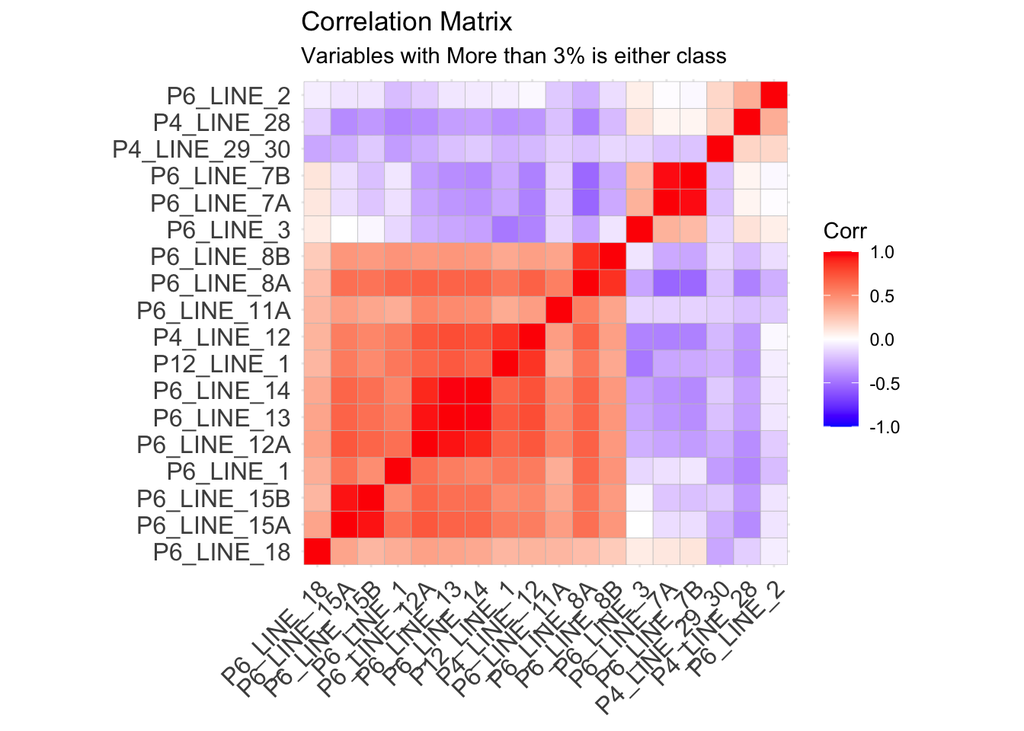

```r
ggcorrplot(corr_mat$correlations,
           hc.order = TRUE ) +
  ggtitle("Correlation Matrix") +
  labs(subtitle = "Variables with More than 3% is either class")
```

## Factor Analysis

### 2 factors

```r
### EFA using minimum residual
faPC2 <- fa(r=corr_mat$correlations,
           nfactors=2,
           n.obs=nrow(design_mat),
           rotate="varimax")
```

```
## In smc, smcs < 0 were set to .0
## In smc, smcs < 0 were set to .0
## In smc, smcs < 0 were set to .0
```

```r
# Tucker-Lewis Index (TLI). An acceptable value must be greater over 0.9.
faPC2$TLI
```

```
## [1] 0.1879976
```

```r
#root mean square of residuals (RMSR). An acceptable value should be closer to 0.
faPC2$rms
```

```
## [1] 0.0743768
```

```r
#loadings
faPC2$loadings
```

```
##
## Loadings:
##               MR1    MR2
## P12_LINE_1     0.679  0.370
## P4_LINE_12     0.680  0.496
## P4_LINE_28    -0.472
## P4_LINE_29_30 -0.419  0.223
## P6_LINE_1      0.729  0.102
## P6_LINE_11A    0.525  0.184
## P6_LINE_12A    0.837  0.353
## P6_LINE_13     0.793  0.428
## P6_LINE_14     0.758  0.448
## P6_LINE_15A    0.841
## P6_LINE_15B    0.728  0.170
## P6_LINE_18     0.512 -0.114
## P6_LINE_2     -0.205
## P6_LINE_3     -0.121 -0.422
## P6_LINE_7A           -0.941
## P6_LINE_7B           -0.938
## P6_LINE_8A     0.697  0.540
## P6_LINE_8B     0.500  0.313
##
##                  MR1   MR2
## SS loadings    6.327 3.373
## Proportion Var 0.351 0.187
## Cumulative Var 0.351 0.539
```

### 3 Factors

```r
### EFA using minimum residual
faPC3 <- fa(r=corr_mat$correlations,
           nfactors=3,
           n.obs=nrow(design_mat),
           rotate="varimax")
```

```
## In smc, smcs < 0 were set to .0
## In smc, smcs < 0 were set to .0
## In smc, smcs < 0 were set to .0
```

```r
# Tucker-Lewis Index (TLI). An acceptable value must be greater over 0.9.
faPC3$TLI
```

```
## [1] 0.1488481
```

```r
#root mean square of residuals (RMSR). An acceptable value should be closer to 0.
faPC3$rms
```

```
## [1] 0.05822424
```

```r
#loadings
faPC3$loadings
```

```
##
## Loadings:
##               MR1    MR3    MR2
## P12_LINE_1     0.766  0.187 -0.211
## P4_LINE_12     0.782  0.209 -0.337
## P4_LINE_28    -0.326 -0.367
## P4_LINE_29_30 -0.278 -0.240 -0.303
## P6_LINE_1      0.548  0.503
## P6_LINE_11A    0.417  0.368
## P6_LINE_12A    0.848  0.332 -0.161
## P6_LINE_13     0.885  0.236 -0.242
## P6_LINE_14     0.843  0.240 -0.271
## P6_LINE_15A    0.666  0.513
## P6_LINE_15B    0.584  0.470
## P6_LINE_18     0.417  0.233  0.219
## P6_LINE_2            -0.300
## P6_LINE_3     -0.297         0.385
## P6_LINE_7A    -0.131 -0.129  0.925
## P6_LINE_7B    -0.146 -0.120  0.916
## P6_LINE_8A     0.430  0.825 -0.427
## P6_LINE_8B     0.236  0.677 -0.234
##
##                  MR1   MR3   MR2
## SS loadings    5.396 2.689 2.555
## Proportion Var 0.300 0.149 0.142
## Cumulative Var 0.300 0.449 0.591
```

Ultra haywood case : “An ultra-Heywood case implies that some unique factor has negative variance… Possible causes include the following:

- bad prior communality estimates
- too many common factors
- too few common factors
- not enough data to provide stable estimates
- the common factor model is not an appropriate model for the data”

https://documentation.sas.com/doc/en/pgmsascdc/9.4_3.4/statug/statug_factor_details10.htm

### Exploring Highly Correlated Variables

Let’s try to remove some of the near perfect correlations and see what happens:

```r
dat_cor <- as.data.frame(corr_mat$correlations)
dat_cor$var1 <- rownames(dat_cor)

dat_cor%>%
  pivot_longer(!var1, names_to = "var2", values_to = "cor") %>%
  filter(var1 != var2) %>%
  arrange(desc(abs(cor))) %>%
  filter(abs(cor) >= 0.90)
```

```
## # A tibble: 8 × 3
##   var1        var2          cor
##   <chr>       <chr>       <dbl>
## 1 P6_LINE_13  P6_LINE_14  0.958
## 2 P6_LINE_14  P6_LINE_13  0.958
## 3 P6_LINE_7A  P6_LINE_7B  0.949
## 4 P6_LINE_7B  P6_LINE_7A  0.949
## 5 P6_LINE_15A P6_LINE_15B 0.939
## 6 P6_LINE_15B P6_LINE_15A 0.939
## 7 P6_LINE_12A P6_LINE_13  0.936
## 8 P6_LINE_13  P6_LINE_12A 0.936
```

First, look at correlations of P6_line 12A, 13, 14. They are quite strong so let’s make a new variable. P6_Line_12_13_14 = 1 if (P6_Line_13 == yes AND P6_Line_14 == yes AND P6_Line_12A == yes) and 0 otherwise. These all get a a similar sentiment: do you have documented policies?

```r
## All 3 are very correlated
design_mat %>%
  select(P6_LINE_13, P6_LINE_14, P6_LINE_12A) %>%
  mutate_all(as.factor) %>%
  hetcor(ML = TRUE)
```

```
##
## Maximum-Likelihood Estimates
##
## Correlations/Type of Correlation:
##             P6_LINE_13 P6_LINE_14 P6_LINE_12A
## P6_LINE_13           1 Polychoric  Polychoric
## P6_LINE_14      0.9579          1  Polychoric
## P6_LINE_12A     0.9362     0.8932           1
##
## Standard Errors:
##             P6_LINE_13 P6_LINE_14
## P6_LINE_13
## P6_LINE_14    0.001039
## P6_LINE_12A   0.001544   0.002071
##
## n = 64139
```

```r
## Even combing 13 and 14 is still very correlated
design_mat %>%
  select(P6_LINE_13, P6_LINE_14, P6_LINE_12A) %>%
  mutate(P6_LINE_13_14 = P6_LINE_13 == 1 & P6_LINE_14 == 1) %>%
  select(-c(P6_LINE_13, P6_LINE_14)) %>%
  mutate_all(as.factor) %>%
  hetcor(ML = TRUE)
```

```
##
## Maximum-Likelihood Estimates
##
## Correlations/Type of Correlation:
##               P6_LINE_12A P6_LINE_13_14
## P6_LINE_12A             1    Polychoric
## P6_LINE_13_14      0.9305             1
##
## Standard Errors:
## [1] ""        "0.00171"
##
## n = 64139
```

```r
design_mat <- design_mat %>%
  mutate(P6_LINE_12_13_14 = as.numeric(
    P6_LINE_12A == 1 & P6_LINE_13 == 1 & P6_LINE_14 == 1)) %>%
  select(-c(P6_LINE_12A, P6_LINE_13, P6_LINE_14))
```

- P6_LINE_6 = Did the organization have members or stockholders?
- P6_Line_7A = Did the organization have members, stockholders, or other persons who had the power to elect one or more members of the governing body?
- P6_Line_7B = Are any governance decisions of the organization reserved to (or subject to approval by) members, stockholders, or persons other than the governing body?

```r
design_mat %>%
  select(P6_LINE_7A, P6_LINE_7B) %>%
  mutate_all(as.factor) %>%
  hetcor(ML = TRUE)
```

[output not shown]

```r
design_mat <-
  design_mat %>%
  mutate(P6_LINE_7 = as.numeric(P6_LINE_7A == 1 & P6_LINE_7B == 1)) %>%
  select(!c(P6_LINE_7B, P6_LINE_7A))
```

For this one, let’s just keep P6_Line_15A. It get’s at the main point. And most people aren’t doing one or the other. Most people do both or neither.

- P6_LINE_15A = compensation review and approval for CEO?
- P6_LINE_15B = compensation review and approval for other officers and key employees?

```r
design_mat %>%
  select(P6_LINE_15A, P6_LINE_15B) %>%
  mutate(P6_LINE_15A = as.factor(P6_LINE_15A),
         P6_LINE_15B = as.factor(P6_LINE_15B)) %>%
  hetcor(ML = TRUE)
```

```
##
## Maximum-Likelihood Estimates
##
## Correlations/Type of Correlation:
##             P6_LINE_15A P6_LINE_15B
## P6_LINE_15A           1  Polychoric
## P6_LINE_15B      0.9388           1
##
## Standard Errors:
## [1] ""        "0.00146"
##
## n = 64139
```

```r
design_mat <-
  design_mat %>%
  select(-P6_LINE_15B)
```

I am also going to remove P6_Line_8B. It is causing non-positive-definite issues and is very highly correlated with 8A.

```r
design_mat <-
  design_mat %>%
  select(-P6_LINE_8B)
```

#### Trying the Correlations Again without the problematic variables

I decided the remove P6_Line_7 entirely because its removal makes the factors analysis incredibly clean. I will talk to Jesse about the implications of this.

```r
#updated the variables to keep
#add the variables I added
adding <- c("P6_LINE_12_13_14")
vars_keep2 <- c(vars_keep, adding)
 #remove the variables I removed
removing <- c("P6_LINE_7A", "P6_LINE_7B",
              "P6_LINE_13", "P6_LINE_14", "P6_LINE_12", "P6_LINE_12A",
              "P6_LINE_15B",
              "P6_LINE_8B",
              "P6_LINE_7")

vars_keep2 <- vars_keep2[!(vars_keep2 %in% removing)]

design_mat2 <- sapply(design_mat[, ..vars_keep2], as.factor) #note the ..vars_keep. the ".." is deliberalty needed in datatable package updates


corr_mat2 <- hetcor(design_mat2, ML = TRUE)
```

```
## data contain one or more character variables
## the values of which are ordered alphabetically
```

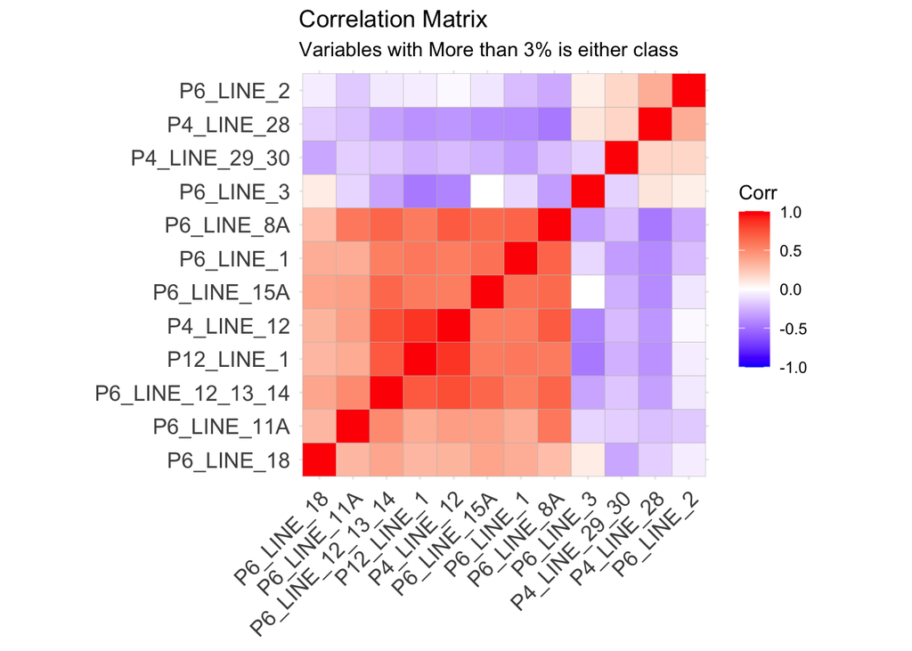

```r
ggcorrplot(corr_mat2$correlations,
           hc.order = TRUE ) +
  ggtitle("Correlation Matrix") +
  labs(subtitle = "Variables with More than 3% is either class")
```

### Trying factor analysis again with new set of variables

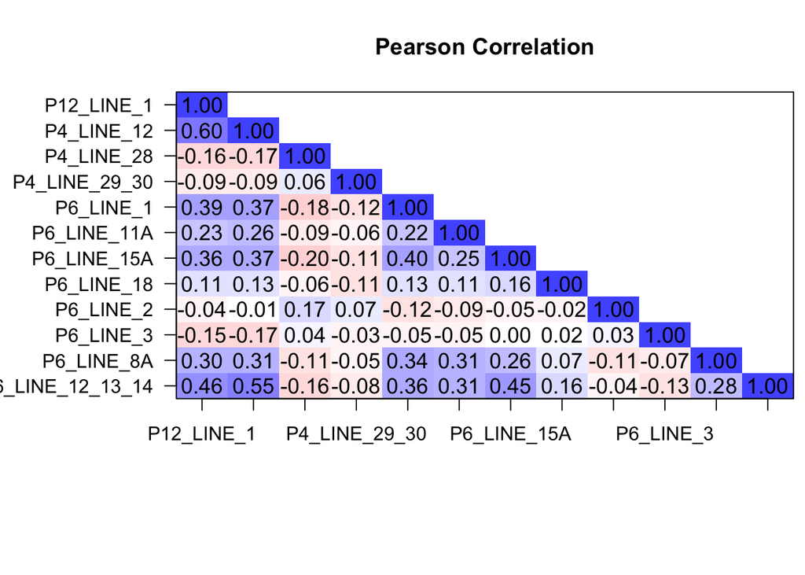

```r
features2 <-  matrix(
  as.numeric(design_mat2), ncol = ncol(design_mat2))

colnames(features2) <- colnames(design_mat2)

#remove 12B for some reason
#features2 <- features2[-6, -6]

## Pearson Correlation
pear_cor2 = cor(features2)
cor.plot(pear_cor2, numbers=T, upper=FALSE, main = "Pearson Correlation", show.legend = FALSE)
```

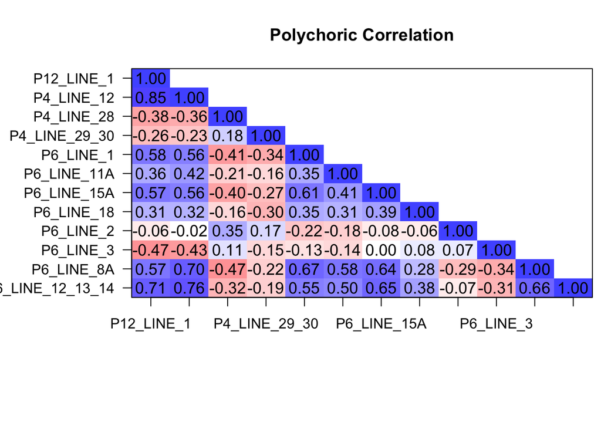

```r
## Polychoric correlation
poly_cor2 = polychoric(features2)
rho2 = poly_cor2$rho

### Thresholds/Scaling results
#poly_cor2$tau
cor.plot(poly_cor2$rho, numbers=T, upper=FALSE, main = "Polychoric Correlation", show.legend = FALSE)
```

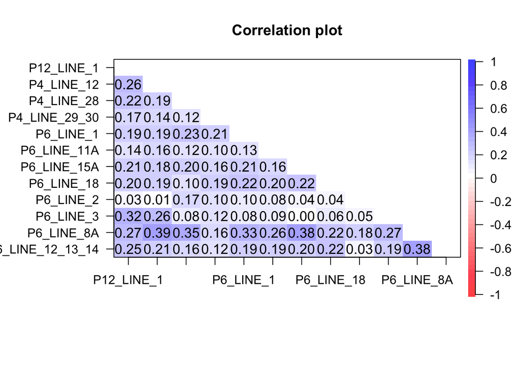

```r
### Plot the difference
#quite a differnce in some places, we will stick with the poly corrs

diff2 = (poly_cor2$rho - pear_cor2)*((pear_cor2>=0)*2-1)
cor.plot(diff2, numbers=T, upper=FALSE, diag=FALSE)
```

There is quite a difference between Pearson and Polychoric correlation. Let’s stick with the polychoric correlation.

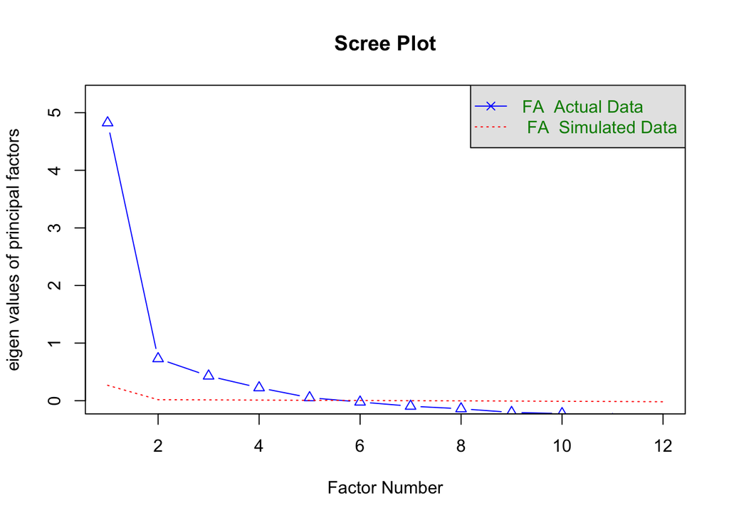

```
## Parallel analysis suggests that the number of factors =  5  and the number of components =  NA
```

```r
# Scree plot to find number of dimensions
# note that this method is not designed for polychoric corr's so these are just a general place to start
fa.parallel(rho2,
            fm="pa",
            fa="fa",
            main = "Scree Plot",
            cor = "poly",
            nfactors = 1,
            n.obs = nrow(design_mat_keep))
```